# Google Data Analytics Professional Certificate: Bellabeat - How can a Wellness Technology Company Play it Smart

Alexander Karl Rivera

2023-01-03

# 1 Introduction

This project serves as the capstone project for the Google Data Analytics Professional Certificate.

[**Bellabeat**](https://bellabeat.com/) is a successful small company which is high-tech manufacturer of health-focused products for women, furthermore they have a potential to become a major player in the global smart device market.

## 1.1 Stakeholders:

- Urška Sršen: Bellabeat’s cofounder and Chief Creative Officer
- Sando Mur: Mathematician and Bellabeat’s cofounder; key member of the Bellabeat executive team
- Bellabeat marketing analytics team: A team of data analysts responsible for collecting, analyzing, and reporting data that helps guide Bellabeat’s marketing strategy.

## 1.2 Products:

- Bellabeat app: The Bellabeat app provides users with health data related to their activity, sleep, stress, menstrual cycle, and mindfulness habits. This data can help users better understand their current habits and make healthy decisions. The Bellabeat app connects to their line of smart wellness products.
- Leaf: Bellabeat’s classic wellness tracker can be worn as a bracelet, necklace, or clip. The Leaf tracker connects to the Bellabeat app to track activity, sleep, and stress.
- Time: This wellness watch combines the timeless look of a classic timepiece with smart technology to track user activity, sleep, and stress. The Time watch connects to the Bellabeat app to provide you with insights into your daily wellness.
- Spring: This is a water bottle that tracks daily water intake using smart technology to ensure that you are appropriately hydrated throughout the day. The Spring bottle connects to the Bellabeat app to track your hydration levels.
- Bellabeat membership: Bellabeat also offers a subscription-based membership program for users. Membership gives users 24/7 access to fully personalized guidance on nutrition, activity, sleep, health and beauty, and mindfulness based on their lifestyle and goals.

# 2 Business Task

Sršen has tasked us to analyzed smart device usage data in order to gain insight into how consumers use non-Bellabeat smart devices and apply these insights to one of the Bellabeat products.

- Check the different smart device usage trends
- Examine the applicability of these trends to Bellabeat customers
- Explore on how these trends can help influence Bellabeat marketing strategy

# 3 Prepare; Data Source, Type, Credibility ,Privacy Ethics and Limitations

## 3.1 Data Source and Type

The original datasets can be referenced under [zenodo.org](https://zenodo.org/record/53894). There are two datasets which covers the period from March to May 12, 2016. Each datasets have a data timeframe of one month and are saved into csv types.

## 3.2 Data Licensing

The Dataset has been licensed as [CC0: Public Domain information](https://creativecommons.org/publicdomain/zero/1.0/).

## 3.3 Data Privacy

The dataset has omitted any private information of the respondents.

## 3.4 Data Credibility

- Reliable: Yes - Low

The dataset includes the generally accepted sample size of 30 respondents.

- Original: Yes - High

The data was generated by Fitbit users who responded to the survey conducted by Amazon Mechanical Turk. [Amazon Mechanical Turk (MTurk)](https://www.mturk.com/) is a crowdsourcing marketplace that makes it easier for individuals and businesses to outsource their processes and jobs to a distributed workforce who can perform these tasks virtually. MTurk is a secondary-party data provider.

- Comprehensive: Yes - Medium

The dataset includes the physical activity, heart-rate, sleep monitoring and weight in three timeframes: daily, hourly and minute. However the dataset do not provide any demographic information, which could have been necessary information for this analysis.

- Current: No - Low

The dataset is based on a 2016 survey. There have been no update on the data with sufficient sample size since then.

- Cited: Yes - High

The dataset referenced under [zenodo.org](https://zenodo.org/record/53894) have cited the authors, publication date, Digital Object Identifier and Licensing.

Based on the assessment above, the data can be considerate as moderately credible.

## 3.5 Data Limitations

- The dataset is based on a 2016 survey and may not represent current customer trend. We can disregard this limitation for this case study.
- The data does not include any information on the Fitbit users demography. This information will enable that analysis will only focus on female, who are the target customer. I will be assuming that all of the data points are from female participants.
- The dataset only covers a one month timeframe - the timeframe is too short to cover for long term habits and benefits of using the Fitbit app.

# 4 Process - Data Cleaning

I will be utilizing the Kaggle Notebook R for this analysis. This tool provide ease of data exploration, cleaning, mutation, transformation, visualization and reporting of the analysis. Furthermore, it provide simpler referencing of the analysis and source file.

## 4.1 Loading the necessary packages

```r
library(tidyverse)
library(lubridate)
library(readr)
library(here)
library(janitor)
```

```r
library(ggplot2)
```

## 4.2 Datasets

There are 18 csv files included in the dataset but for the purpose of this study, I will utilized six files. One summary file and five daily tracker will be used for the analysis. These data are listed below.

```r
DailyActivity <- read.csv("../data/FitBit-Fitness-Tracker-Data/dailyActivity_merged.csv")
DailyCalories <- read.csv("../data/FitBit-Fitness-Tracker-Data/dailyCalories_merged.csv")
DailyIntensities <- read.csv("../data/FitBit-Fitness-Tracker-Data/dailyIntensities_merged.csv")
DailySteps <- read.csv("../data/FitBit-Fitness-Tracker-Data/dailySteps_merged.csv")
DailySleep <- read.csv("../data/FitBit-Fitness-Tracker-Data/sleepDay_merged.csv")
weightLogInfo <- read.csv("../data/FitBit-Fitness-Tracker-Data/weightLogInfo_merged.csv")
```

DailyActivity - summary of daily activity data. It summarizes the data from DailyCalories, DailyIntensities and DailySteps data. DailyCalories - Daily calories tracker data DailyIntensities - Daily activity intensity level tracker data DailySteps - Daily steps tracker data DailySleep - Daily sleep tracker data weightLogInfo - weight log tracker data

The data are imported into different dataframes.

**Explore the dataframe**

```r
head(DailyActivity) #For reporting, I will only be showing the main summary
```

```
##           Id ActivityDate TotalSteps TotalDistance TrackerDistance
## 1 1503960366    4/12/2016      13162          8.50            8.50
## 2 1503960366    4/13/2016      10735          6.97            6.97
## 3 1503960366    4/14/2016      10460          6.74            6.74
## 4 1503960366    4/15/2016       9762          6.28            6.28
## 5 1503960366    4/16/2016      12669          8.16            8.16
## 6 1503960366    4/17/2016       9705          6.48            6.48
##   LoggedActivitiesDistance VeryActiveDistance ModeratelyActiveDistance
## 1                        0               1.88                     0.55
## 2                        0               1.57                     0.69
## 3                        0               2.44                     0.40
## 4                        0               2.14                     1.26
## 5                        0               2.71                     0.41
## 6                        0               3.19                     0.78
##   LightActiveDistance SedentaryActiveDistance VeryActiveMinutes
## 1                6.06                       0                25
## 2                4.71                       0                21
## 3                3.91                       0                30
## 4                2.83                       0                29
## 5                5.04                       0                36
## 6                2.51                       0                38
##   FairlyActiveMinutes LightlyActiveMinutes SedentaryMinutes Calories
## 1                  13                  328              728     1985
## 2                  19                  217              776     1797
## 3                  11                  181             1218     1776
## 4                  34                  209              726     1745
## 5                  10                  221              773     1863
## 6                  20                  164              539     1728
```

```r
#head(DailyCalories)
#head(DailyIntensities)
#head(DailySteps)
#head(DailySleep)
#head(weightLogInfo)
```

Based on the unique number check, two dataframes have participants who did not submitted their data - these dataframes are for the DailySleep ( 9 did not submit) and WeightLog ( 25 did not submit)

## 4.3 Data Cleaning and Transformation

This process will check for any null observations, duplicates and other inconsistencies in the databases.

**Column name Formatting**

I will be utilizing the “snake_case” for the consistency of the column names case formatting.

```r
column_formatting <- "snake"

# Using the clean_names under the janitor package

DailyActivity <- clean_names(DailyActivity, "snake")
DailyCalories<- clean_names(DailyCalories, "snake")
DailyIntensities <- clean_names(DailyIntensities, "snake")
DailySteps <- clean_names(DailySteps, "snake")
DailySleep <- clean_names(DailySleep, "snake")
weightLogInfo <- clean_names(weightLogInfo, "snake")
```

```r
#Checking if dataframe columns have been updated
head(DailyActivity) #For reporting, I will only be showing the main summary
```

```
##           id activity_date total_steps total_distance tracker_distance
## 1 1503960366     4/12/2016       13162           8.50             8.50
## 2 1503960366     4/13/2016       10735           6.97             6.97
## 3 1503960366     4/14/2016       10460           6.74             6.74
## 4 1503960366     4/15/2016        9762           6.28             6.28
## 5 1503960366     4/16/2016       12669           8.16             8.16
## 6 1503960366     4/17/2016        9705           6.48             6.48
##   logged_activities_distance very_active_distance moderately_active_distance
## 1                          0                 1.88                       0.55
## 2                          0                 1.57                       0.69
## 3                          0                 2.44                       0.40
## 4                          0                 2.14                       1.26
## 5                          0                 2.71                       0.41
## 6                          0                 3.19                       0.78
##   light_active_distance sedentary_active_distance very_active_minutes
## 1                  6.06                         0                  25
## 2                  4.71                         0                  21
## 3                  3.91                         0                  30
## 4                  2.83                         0                  29
## 5                  5.04                         0                  36
## 6                  2.51                         0                  38
##   fairly_active_minutes lightly_active_minutes sedentary_minutes calories
## 1                    13                    328               728     1985
## 2                    19                    217               776     1797
## 3                    11                    181              1218     1776
## 4                    34                    209               726     1745
## 5                    10                    221               773     1863
## 6                    20                    164               539     1728
```

```r
#head(DailyCalories)
#head(DailyIntensities)
#head(DailySteps)
#head(DailySleep)
#head(weightLogInfo)
```

**Date and Time Formatting**

Based on the head function above, the dates are in “character” type - these data should be in date, time or datetime format. I will be adding a new column for the time and for the day of the week data.

```r
DailyActivity <- DailyActivity %>%
  mutate(activity_date = mdy(activity_date), day_of_week = wday(activity_date, label = TRUE), total_minutes = very_active_minutes +  fairly_active_minutes + lightly_active_minutes + sedentary_minutes)

DailyCalories <- DailyCalories %>%
  rename(activity_date = activity_day) %>%
  mutate(activity_date = mdy(activity_date), day_of_week = wday(activity_date, label = TRUE))

DailyIntensities <- DailyIntensities %>%
  rename(activity_date = activity_day) %>%
  mutate(activity_date = mdy(activity_date), day_of_week = wday(activity_date, label = TRUE), total_minutes = very_active_minutes +  fairly_active_minutes + lightly_active_minutes + sedentary_minutes)

DailySteps <- DailySteps %>%
  rename(activity_date = activity_day) %>%
  mutate(activity_date = mdy(activity_date), day_of_week = wday(activity_date, label = TRUE))

DailySleep <- DailySleep %>%
  rename(activity_date = sleep_day) %>%
  mutate(activity_date = date(mdy_hms(activity_date)), day_of_week = wday(activity_date, label = TRUE))

weightLogInfo <- weightLogInfo %>%
  rename(activity_date = date) %>%
  mutate(activity_date = date(mdy_hms(activity_date)), day_of_week = wday(activity_date, label = TRUE))
```

**Intensity Time Consistency**

There is a provided time for the intensity (in minutes) for the DailyActivity and DailyIntensities datasets, to verify that there are no issues in the datasets, I will check if total_minutes is less than or equal to 1,440 minutes (24 hour-period). A return value of zero means that there all value are within the 24-hour period.

```r
c(DailyActivity = DailyActivity %>%
  filter(total_minutes > 1440) %>%
  sum())
```

```
## DailyActivity
##             0
```

```r
c(DailyIntensities = DailyIntensities %>%
  filter(total_minutes > 1440) %>%
  sum())
```

```
## DailyIntensities
##                0
```

**Data Consistency**

I cross-checked the values provided in the individual tracker to the summary data. If there is a difference between the the individual data tracker and the summary, I will utilize the provided observation on the individual tracker. A return value of zero means that there is no issue with the dataset.

```r
#Check for possible inconsintencies between the DailyActivity and DailyCalories
merge(DailyActivity, DailyCalories, by = c("id", "activity_date")) %>%
  filter(calories.x != calories.y) %>%
  sum()
```

```
## [1] 0
```

```r
#Check for possible inconsintencies between the DailyActivity and DailyIntensities
merge(DailyActivity, DailyIntensities, by = c("id", "activity_date")) %>%
  filter(total_minutes.x != total_minutes.y) %>%
  sum()
```

```
## [1] 0
```

```r
#Check for possible inconsintencies between the DailyActivity and DailySteps
merge(DailyActivity, DailySteps, by = c("id", "activity_date")) %>%
  filter(total_steps != step_total) %>%
  sum()
```

```
## [1] 0
```

**Check for duplicate data**

```r
# The duplicated function will check for duplicate rows and return it as TRUE. In consideration, Boolean True has a value of 1 and Boolean FALSE has a value of 0, so if we summed up the dataframes that have no duplicates it will return to zero

tibble("DailyActivity" = sum(duplicated(DailyActivity)),
       DailyCalories = sum(duplicated(DailyCalories)),
       DailyIntensities = sum(duplicated(DailyIntensities)),
       DailySteps = sum(duplicated(DailySteps)),
       DailySleep = sum(duplicated(DailySleep)),
       weightLogInfo = sum(duplicated(weightLogInfo)))
```

```
## # A tibble: 1 × 6
##   DailyActivity DailyCalories DailyIntensities DailySteps DailySleep weightLog…¹
##           <int>         <int>            <int>      <int>      <int>       <int>
## 1             0             0                0          0          3           0
## # … with abbreviated variable name ¹weightLogInfo
```

Based on the nested function above, the DailySleep have 3 duplicate rows. I will now removed all the duplicate rows.

```r
#There are 413 observations in the initial dataset including the 3 duplicates
DailySleep <- distinct(DailySleep)

#Check if the duplicate rows have been removed. It should return 410.
tibble(distinct_sleep_observation = nrow(DailySleep))
```

```
## # A tibble: 1 × 1
##   distinct_sleep_observation
##                        <int>
## 1                        410
```

**Check for missing values**

```r
# The is.na function will check for blank data and return it as TRUE. In consideration, Boolean True has a value of 1 and Boolean FALSE has a value of 0, so if we summed up the dataframes that have blank data it will return to zero

sum(is.na(DailyActivity))
```

```
## [1] 0
```

```r
sum(is.na(DailyCalories))
```

```
## [1] 0
```

```r
sum(is.na(DailyIntensities))
```

```
## [1] 0
```

```r
sum(is.na(DailySteps))
```

```
## [1] 0
```

```r
sum(is.na(DailySleep))
```

```
## [1] 0
```

```r
sum(is.na(weightLogInfo))
```

```
## [1] 65
```

I will now verify where is the missing value in the WeightLogInfo datasets by creating a summary and checking what row have the NULL values and verify if it will have an impact on my analysis.

```r
# Checking for the number of the unique ID

summary(weightLogInfo)
```

```
##        id            activity_date          weight_kg      weight_pounds
##  Min.   :1.504e+09   Min.   :2016-04-12   Min.   : 52.60   Min.   :116.0
##  1st Qu.:6.962e+09   1st Qu.:2016-04-19   1st Qu.: 61.40   1st Qu.:135.4
##  Median :6.962e+09   Median :2016-04-27   Median : 62.50   Median :137.8
##  Mean   :7.009e+09   Mean   :2016-04-26   Mean   : 72.04   Mean   :158.8
##  3rd Qu.:8.878e+09   3rd Qu.:2016-05-04   3rd Qu.: 85.05   3rd Qu.:187.5
##  Max.   :8.878e+09   Max.   :2016-05-12   Max.   :133.50   Max.   :294.3
##
##       fat             bmi        is_manual_report       log_id
##  Min.   :22.00   Min.   :21.45   Length:67          Min.   :1.460e+12
##  1st Qu.:22.75   1st Qu.:23.96   Class :character   1st Qu.:1.461e+12
##  Median :23.50   Median :24.39   Mode  :character   Median :1.462e+12
##  Mean   :23.50   Mean   :25.19                      Mean   :1.462e+12
##  3rd Qu.:24.25   3rd Qu.:25.56                      3rd Qu.:1.462e+12
##  Max.   :25.00   Max.   :47.54                      Max.   :1.463e+12
##  NA's   :65
##  day_of_week
##  Sun:10
##  Mon:12
##  Tue: 9
##  Wed:12
##  Thu:11
##  Fri: 6
##  Sat: 7
```

All of the missing values are located under the “Fat” column. I choose to omit this column as it will not have an impact on my analysis and to have consistency on the dataframes with values.

**Merge Datasets**

To simplify the analysis process for correlations, I will be merging the different information into one summary dataframe. I will be adding the weightLogInfo and DailySleep into the DailyActivity dataframe.

```r
DailySummary <- DailyActivity %>%
  full_join(DailySleep[-6], by = c("activity_date","id")) %>%
  full_join(weightLogInfo[-8], by = c("activity_date","id"))

str(DailySummary)
```

```
## 'data.frame':    940 obs. of  25 variables:
##  $ id                        : num  1.5e+09 1.5e+09 1.5e+09 1.5e+09 1.5e+09 ...
##  $ activity_date             : Date, format: "2016-04-12" "2016-04-13" ...
##  $ total_steps               : int  13162 10735 10460 9762 12669 9705 13019 15506 10544 9819 ...
##  $ total_distance            : num  8.5 6.97 6.74 6.28 8.16 ...
##  $ tracker_distance          : num  8.5 6.97 6.74 6.28 8.16 ...
##  $ logged_activities_distance: num  0 0 0 0 0 0 0 0 0 0 ...
##  $ very_active_distance      : num  1.88 1.57 2.44 2.14 2.71 ...
##  $ moderately_active_distance: num  0.55 0.69 0.4 1.26 0.41 ...
##  $ light_active_distance     : num  6.06 4.71 3.91 2.83 5.04 ...
##  $ sedentary_active_distance : num  0 0 0 0 0 0 0 0 0 0 ...
##  $ very_active_minutes       : int  25 21 30 29 36 38 42 50 28 19 ...
##  $ fairly_active_minutes     : int  13 19 11 34 10 20 16 31 12 8 ...
##  $ lightly_active_minutes    : int  328 217 181 209 221 164 233 264 205 211 ...
##  $ sedentary_minutes         : int  728 776 1218 726 773 539 1149 775 818 838 ...
##  $ calories                  : int  1985 1797 1776 1745 1863 1728 1921 2035 1786 1775 ...
##  $ day_of_week               : Ord.factor w/ 7 levels "Sun"<"Mon"<"Tue"<..: 3 4 5 6 7 1 2 3 4 5 ...
##  $ total_minutes             : int  1094 1033 1440 998 1040 761 1440 1120 1063 1076 ...
##  $ total_sleep_records       : int  1 2 NA 1 2 1 NA 1 1 1 ...
##  $ total_minutes_asleep      : int  327 384 NA 412 340 700 NA 304 360 325 ...
##  $ total_time_in_bed         : int  346 407 NA 442 367 712 NA 320 377 364 ...
##  $ weight_kg                 : num  NA NA NA NA NA NA NA NA NA NA ...
##  $ weight_pounds             : num  NA NA NA NA NA NA NA NA NA NA ...
##  $ bmi                       : num  NA NA NA NA NA NA NA NA NA NA ...
##  $ is_manual_report          : chr  NA NA NA NA ...
##  $ log_id                    : num  NA NA NA NA NA NA NA NA NA NA ...
```

# 5 Analyze

The data has now been cleaned for analysis. This section will focus on gaining insights from the datasets.

## 5.1 Summary Data

The **DailySummary** covers a time period of 31 days from 2016-04-12 to 2016-05-12.

```r
# Summary on the Datasets
DailySummary %>%
  select(total_steps, total_distance,sedentary_minutes,total_minutes,calories,total_minutes_asleep,weight_kg, bmi) %>%
  summary()
```

```
##   total_steps    total_distance   sedentary_minutes total_minutes
##  Min.   :    0   Min.   : 0.000   Min.   :   0.0    Min.   :   2.0
##  1st Qu.: 3790   1st Qu.: 2.620   1st Qu.: 729.8    1st Qu.: 989.8
##  Median : 7406   Median : 5.245   Median :1057.5    Median :1440.0
##  Mean   : 7638   Mean   : 5.490   Mean   : 991.2    Mean   :1218.8
##  3rd Qu.:10727   3rd Qu.: 7.713   3rd Qu.:1229.5    3rd Qu.:1440.0
##  Max.   :36019   Max.   :28.030   Max.   :1440.0    Max.   :1440.0
##
##     calories    total_minutes_asleep   weight_kg           bmi
##  Min.   :   0   Min.   : 58.0        Min.   : 52.60   Min.   :21.45
##  1st Qu.:1828   1st Qu.:361.0        1st Qu.: 61.40   1st Qu.:23.96
##  Median :2134   Median :432.5        Median : 62.50   Median :24.39
##  Mean   :2304   Mean   :419.2        Mean   : 72.04   Mean   :25.19
##  3rd Qu.:2793   3rd Qu.:490.0        3rd Qu.: 85.05   3rd Qu.:25.56
##  Max.   :4900   Max.   :796.0        Max.   :133.50   Max.   :47.54
##                 NA's   :530          NA's   :873      NA's   :873
```

```r
# Summary of number observations for the different datasets

as.data.frame(tibble("DailyActivity" = nrow(DailyActivity),
      "DailyCalories" = nrow(DailyCalories),
      "DailyIntensities" = nrow(DailyIntensities),
      "DailySteps" = nrow(DailySteps),
      "DailySleep" = nrow(DailySleep),
      "weightLogInfo" = nrow(weightLogInfo)))  %>%
          pivot_longer(cols = c("DailyActivity","DailyCalories", "DailyIntensities", "DailySteps", "DailySleep", "weightLogInfo"), names_to = "feature", values_to = "observation")
```

```
## # A tibble: 6 × 2
##   feature          observation
##   <chr>                  <int>
## 1 DailyActivity            940
## 2 DailyCalories            940
## 3 DailyIntensities         940
## 4 DailySteps               940
## 5 DailySleep               410
## 6 weightLogInfo             67
```

```r
# Summary of participants for each activity

ParticipantSummary <- as.data.frame(tibble("DailyActivity" = n_distinct(DailyActivity$id),
                             "DailyCalories" = n_distinct(DailyCalories$id),
                             "DailyIntensities" = n_distinct(DailyIntensities$id),
                             "DailySteps" = n_distinct(DailySteps$id),
                             "DailySleep" = n_distinct(DailySleep$id),
                             "weightLogInfo" = n_distinct(weightLogInfo$id)))

ParticipantSummary <- ParticipantSummary %>%
  pivot_longer(cols = c("DailyActivity","DailyCalories", "DailyIntensities", "DailySteps", "DailySleep", "weightLogInfo"), names_to = "feature", values_to = "participant")

ParticipantSummary
```

```
## # A tibble: 6 × 2
##   feature          participant
##   <chr>                  <int>
## 1 DailyActivity             33
## 2 DailyCalories             33
## 3 DailyIntensities          33
## 4 DailySteps                33
## 5 DailySleep                24
## 6 weightLogInfo              8
```

Upon examination of the provided summary statistics above, I noticed that the minimum value for some of the tracked activities is zero (0) such as total_steps (77), total_distance (85), sedentary_minutes (1) and calories (4). With the consideration that zero data are unfeasible, I have omitted the data in the individual datasets. For the **DailySummary**, these zero-value will be retained but will be filtered out during analysis and visualizations.

```r
# Remove Zero Value Data from the Individual Datasets
CleanedDailySteps <- DailySteps %>%
  filter(step_total != 0)

CleanedDailyCalories <- DailyCalories %>%
  filter(calories != 0)

CleanedDailyIntensities <- DailyIntensities %>%
  filter(sedentary_minutes != 0)
```

## 5.2 Explore Datasets

**Explore Daily Steps**

According to World Health Organization, for general fitness, most adults should aim for 10,000 steps per day. This figure may rise or fall depending on a person’s age, current fitness level, and health goals. This recommendation comes from the Centers for Disease Control and Prevention (CDC).

```r
CleanedDailySteps %>%
  group_by(day_of_week) %>%
  summarise(mean_total_steps = round(mean(step_total),2))  #create a summary of the mean total steps group by day_of_week
```

```
## # A tibble: 7 × 2
##   day_of_week mean_total_steps
##   <ord>                  <dbl>
## 1 Sun                    7627.
## 2 Mon                    8488.
## 3 Tue                    8949.
## 4 Wed                    8158.
## 5 Thu                    8185.
## 6 Fri                    7821.
## 7 Sat                    8947.
```

**Explore Daily Calories**

```r
CleanedDailyCalories %>%
  group_by(day_of_week) %>%
  summarise(mean_calories = mean(calories))
```

```
## # A tibble: 7 × 2
##   day_of_week mean_calories
##   <ord>               <dbl>
## 1 Sun                 2263
## 2 Mon                 2324.
## 3 Tue                 2372.
## 4 Wed                 2303.
## 5 Thu                 2230.
## 6 Fri                 2332.
## 7 Sat                 2374.
```

**Explore Daily Intensities**

```r
# Average number of steps per by day of week
IntensityType <- tibble('avg_sedentary_minutes' = round(mean(CleanedDailyIntensities$sedentary_minutes), digits = 2),
       'avg_lightly_active_minutes' = round(mean(CleanedDailyIntensities$lightly_active_minutes), digits = 2),
       'avg_fairly_active_minutes' = round(mean(CleanedDailyIntensities$fairly_active_minutes), digits = 2),
       'avg_very_active_minutes' = round(mean(CleanedDailyIntensities$very_active_minutes), digits = 2))

IntensityType <- IntensityType %>%
  pivot_longer(cols = c("avg_sedentary_minutes","avg_lightly_active_minutes", "avg_fairly_active_minutes", "avg_very_active_minutes", ), names_to = "intensity_type", values_to = "mean_time")

IntensityType <- IntensityType %>%
  mutate(percentage = round(mean_time/sum(mean_time)*100,2))

IntensityType
```

```
## # A tibble: 4 × 3
##   intensity_type             mean_time percentage
##   <chr>                          <dbl>      <dbl>
## 1 avg_sedentary_minutes          992.       81.3
## 2 avg_lightly_active_minutes     193.       15.8
## 3 avg_fairly_active_minutes       13.6       1.11
## 4 avg_very_active_minutes         21.2       1.74
```

**Explore Daily Sleep**

According from CDC, adults between 18 and 64 years old need seven to eight hours of good-quality sleep per night.

```r
# Convert the time in minutes to hours - sleep time and time in bed
CleanedDailySleep <- DailySleep %>%
  mutate(total_hours_asleep = total_minutes_asleep/60,
         total_hours_in_bed = total_time_in_bed/60)

CleanedDailySleep %>%
  group_by(day_of_week) %>%
  summarise(mean_hours_asleep = mean(total_hours_asleep))
```

```
## # A tibble: 7 × 2
##   day_of_week mean_hours_asleep
##   <ord>                   <dbl>
## 1 Sun                      7.55
## 2 Mon                      6.99
## 3 Tue                      6.74
## 4 Wed                      7.24
## 5 Thu                      6.69
## 6 Fri                      6.76
## 7 Sat                      6.98
```

# 6 Share

This section will visualize the analyze conducted in the previous section. **Daily Steps**

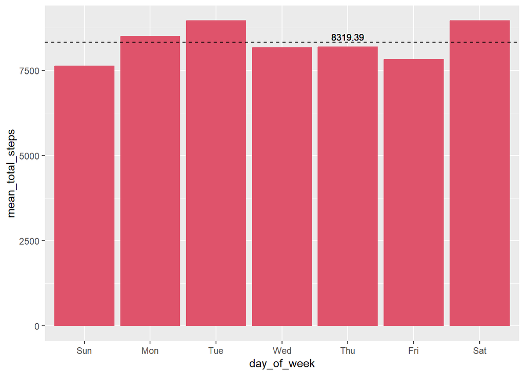

```r
# Average number of steps per by day of week
average_daily_steps <- round(mean(CleanedDailySteps$step_total), digits = 2)

CleanedDailySteps %>%
  group_by(day_of_week) %>%
  summarise(mean_total_steps = round(mean(step_total),2)) %>%
  ggplot() +
    geom_col(mapping = aes(x = day_of_week, mean_total_steps), color = 2, fill = 2) +
    geom_hline(yintercept = average_daily_steps, linetype = 'dashed', color = 9) +
    geom_text(aes(y =average_daily_steps, label = average_daily_steps), x = 5, size = 3, vjust = -0.30)
```

**Daily Calories**

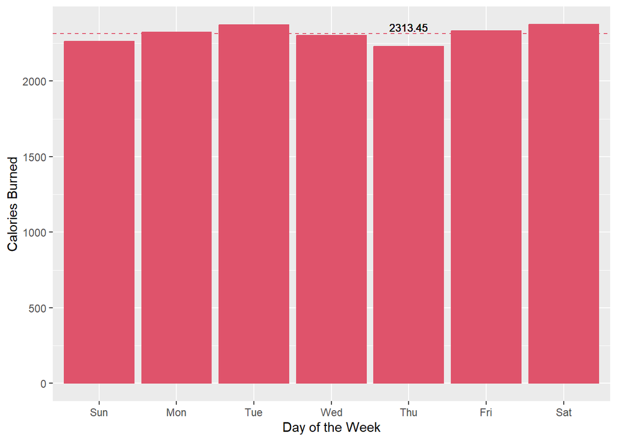

```r
# Average calories burned per by day of week
average_daily_calories <- round(mean(CleanedDailyCalories$calories), digits = 2)

CleanedDailyCalories %>%
  group_by(day_of_week) %>%
  summarise(mean_calories = mean(calories)) %>%  #create a summary of the mean calories burned group by day_of_week
  ggplot() +
    geom_col(mapping = aes(x = day_of_week, mean_calories), color = 2, fill = 2) +
    labs(x="Day of the Week", y="Calories Burned") +
    geom_hline(yintercept = average_daily_calories, linetype = 'dashed', color = 10) +
    geom_text(aes(y =average_daily_calories, label = average_daily_calories), x = 5, size = 3, vjust = -0.30)
```

**Daily Intensities**

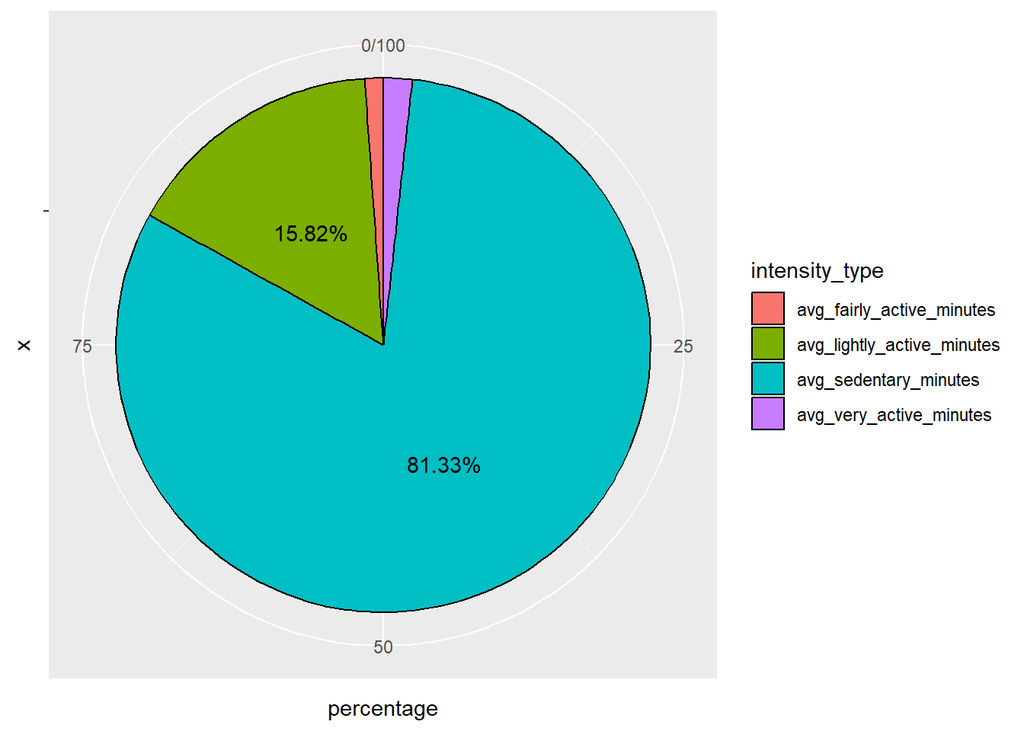

```r
## Create a pie chart to check for the distributions of Intensity minutes.

# Average number of steps per by day of week
IntensityType <- tibble('avg_sedentary_minutes' = round(mean(CleanedDailyIntensities$sedentary_minutes), digits = 2),
       'avg_lightly_active_minutes' = round(mean(CleanedDailyIntensities$lightly_active_minutes), digits = 2),
       'avg_fairly_active_minutes' = round(mean(CleanedDailyIntensities$fairly_active_minutes), digits = 2),
       'avg_very_active_minutes' = round(mean(CleanedDailyIntensities$very_active_minutes), digits = 2))

IntensityType <- IntensityType %>%
  pivot_longer(cols = c("avg_sedentary_minutes","avg_lightly_active_minutes", "avg_fairly_active_minutes", "avg_very_active_minutes", ), names_to = "intensity_type", values_to = "mean_time")

IntensityType <- IntensityType %>%
  mutate(percentage = round(mean_time/sum(mean_time)*100,2)) %>%
  ggplot(aes(x = "", y = percentage, fill = intensity_type)) +
  geom_bar( stat = "identity", width =1, show.legend = TRUE, color = 1) +
  coord_polar(theta = "y") +
  geom_text(aes(label = ifelse(percentage <2,"", paste(round(percentage,digits = 2),"%",sep="")))
            ,position=position_stack(vjust = 0.5)
            , color = 1)

IntensityType
```

**Daily Sleep**

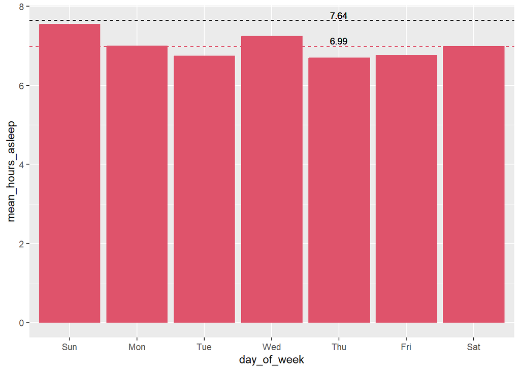

```r
# Convert the time in minutes to hours - sleep time and time in bed
CleanedDailySleep <- DailySleep %>%
  mutate(total_hours_asleep = total_minutes_asleep/60,
         total_hours_in_bed = total_time_in_bed/60)


# Average time by day of week
average_sleep_hours <- round(mean(CleanedDailySleep$total_hours_asleep), digits = 2)
average_in_bed_hours <- round(mean(CleanedDailySleep$total_hours_in_bed), digits = 2)

CleanedDailySleep %>%
  group_by(day_of_week) %>%
  summarise(mean_hours_asleep = mean(total_hours_asleep)) %>%
  ggplot() +
    geom_col(mapping = aes(x = day_of_week, mean_hours_asleep), color = 2, fill = 2) +
    geom_hline(yintercept = average_sleep_hours, linetype = 'dashed', color = 10) +
    geom_hline(yintercept = average_in_bed_hours, linetype = 'dashed', color = 1) +
    geom_text(aes(y =average_sleep_hours, label = average_sleep_hours), x = 5, size = 3, vjust = -0.30) +
    geom_text(aes(y =average_in_bed_hours, label = average_in_bed_hours), x = 5, size = 3, vjust = -0.30)
```

Participants average a 6.99 hours sleeping which is just below the recommended a minimum of 7 hours of good-night sleep. Participants averaged a 39 minutes of staying in the bed after waking up.

**Daily Logging**

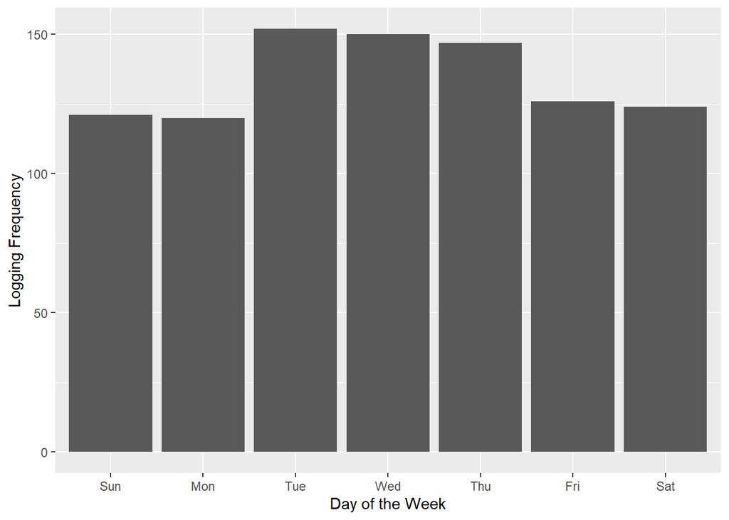

```r
#Check for the number of logged activities
DailyActivity %>%
  group_by(day_of_week) %>%
  ggplot(mapping = aes(x = day_of_week, stat="count"), fill = 2) +
  geom_bar() +
  labs(x="Day of the Week", y="Logging Frequency")
```

# 7 Conclusion

I will be providing my insights and providing my recommendations based on the analysis above.

# 8 Recommendation

This section will provide recommendation on the Bellabeat products based on the analyze smart device usage trend.